# Microarray Analysis

Marta Ibáñez Lligoña

6/6/2019

# 1. Data capture from images or text files

The dataset that I have chosen has the following id: GSE128949. The title of my set is: “Gene Expression data from human mesenchymal stromal cells” in the organism Homo Sapiens.

## Sumary:

Cellular therapy is proposed for tendinopathy treatment. Bone marrow- (BM-MSC) and adipose tissue- (ASC-) derived mesenchymal stromal cells are candidate populations for such a therapy. We used microarrays to evaluate the basal gene expression in human BM-MSCs and ASCs and to create list of differentially expressed genes between analyzed groups.

## Experiment type

Expression profiling by array

## Overall design

The microarray expression analysis was performed on RNA isolated from hASC (n=5) and hBM-MSC cells (n=6) using the Affymetrix Gene Atlas system.

## Citation

The citation is missing.

## Data description

You can find the target file, also an expression matrix and some CEL files.

```r
expression <- as.matrix(read.delim("~/Desktop/Universitat/2_ANY/3_TRIMESTRE/Omics Techniques/Ibanez_Marta-OmicsTechniques/Exercise_3/Data/expression.txt", row.names=1, comment.char="#"))
targets <- read.delim("~/Desktop/Universitat/2_ANY/3_TRIMESTRE/Omics Techniques/Ibanez_Marta-OmicsTechniques/Exercise_3/Data/targets.txt", header=TRUE)
require(Biobase)
```

## Checking the types of files

```r
show(targets)
```

```
##    SampleName Groups       ShortName
## 1  GSM3688814    ASC    ASC_patient1
## 2  GSM3688815    ASC    ASC_patient2
## 3  GSM3688816    ASC    ASC_patient3
## 4  GSM3688817    ASC    ASC_patient4
## 5  GSM3688818    ASC    ASC_patient5
## 6  GSM3688819 BM-MSC BM-MSC_patient1
## 7  GSM3688820 BM-MSC BM-MSC_patient2
## 8  GSM3688821 BM-MSC BM-MSC_patient3
## 9  GSM3688822 BM-MSC BM-MSC_patient4
## 10 GSM3688823 BM-MSC BM-MSC_patient5
## 11 GSM3688824 BM-MSC BM-MSC_patient6
```

```r
dim(expression)
```

```
## [1] 53617    11
```

```r
summary(expression)
```

```
##    GSM3688814       GSM3688815       GSM3688816       GSM3688817
##  Min.   : 2.397   Min.   : 2.337   Min.   : 2.415   Min.   : 2.354
##  1st Qu.: 3.902   1st Qu.: 3.894   1st Qu.: 3.900   1st Qu.: 3.907
##  Median : 4.843   Median : 4.744   Median : 4.815   Median : 4.788
##  Mean   : 5.237   Mean   : 5.072   Mean   : 5.162   Mean   : 5.151
##  3rd Qu.: 6.242   3rd Qu.: 5.924   3rd Qu.: 6.105   3rd Qu.: 6.075
##  Max.   :12.836   Max.   :12.995   Max.   :12.759   Max.   :13.068
##    GSM3688818       GSM3688819       GSM3688820       GSM3688821
##  Min.   : 2.330   Min.   : 2.363   Min.   : 2.322   Min.   : 2.349
##  1st Qu.: 3.913   1st Qu.: 4.001   1st Qu.: 4.065   1st Qu.: 3.898
##  Median : 4.750   Median : 4.855   Median : 4.890   Median : 4.778
##  Mean   : 5.073   Mean   : 5.277   Mean   : 5.410   Mean   : 5.108
##  3rd Qu.: 5.898   3rd Qu.: 6.229   3rd Qu.: 6.343   3rd Qu.: 6.015
##  Max.   :12.767   Max.   :12.905   Max.   :13.251   Max.   :12.871
##    GSM3688822       GSM3688823       GSM3688824
##  Min.   : 2.404   Min.   : 2.308   Min.   : 2.212
##  1st Qu.: 3.927   1st Qu.: 3.918   1st Qu.: 3.919
##  Median : 4.909   Median : 4.811   Median : 4.813
##  Mean   : 5.447   Mean   : 5.179   Mean   : 5.180
##  3rd Qu.: 6.607   3rd Qu.: 6.124   3rd Qu.: 6.131
##  Max.   :12.993   Max.   :12.707   Max.   :12.860
```

```r
class(targets)
```

```
## [1] "data.frame"
```

```r
class(expression)
```

```
## [1] "matrix"
```

```r
mypatient <- paste0("Patient", 1:11)
```

I also decided to create my own information.

```r
myInfo = list(myName= "Marta Ibáñez", myLab = "Bioinformatics Lab", myContact = "marta.ibanez@alum.esci.upf.edu", myTitle = "Practical Exercise on ExpressionSets")
show(myInfo)
```

```
## $myName
## [1] "Marta Ibáñez"
##
## $myLab
## [1] "Bioinformatics Lab"
##
## $myContact
## [1] "marta.ibanez@alum.esci.upf.edu"
##
## $myTitle
## [1] "Practical Exercise on ExpressionSets"
```

## Creating expression set

```r
myEset <- ExpressionSet(expression)
class(myEset)
```

```
## [1] "ExpressionSet"
## attr(,"package")
## [1] "Biobase"
```

```r
show(myEset)
```

```
## ExpressionSet (storageMode: lockedEnvironment)
## assayData: 53617 features, 11 samples
##   element names: exprs
## protocolData: none
## phenoData: none
## featureData: none
## experimentData: use 'experimentData(object)'
## Annotation:
```

## Information about covariates

```r
columnDesc <- data.frame(labelDescription = c("Sample Names", "Patients", "Groups"))
myAnnotDF <- new("AnnotatedDataFrame", data = targets, varMetadata= columnDesc)
show(myAnnotDF)
```

```
## An object of class 'AnnotatedDataFrame'
##   rowNames: 1 2 ... 11 (11 total)
##   varLabels: SampleName Groups ShortName
##   varMetadata: labelDescription
```

```r
phenoData(myEset) <- myAnnotDF
rownames(pData(myAnnotDF)) <- pData(myAnnotDF)$SampleName
myEset <- ExpressionSet(assayData = expression, phenoData = myAnnotDF)
show(myEset)
```

```
## ExpressionSet (storageMode: lockedEnvironment)
## assayData: 53617 features, 11 samples
##   element names: exprs
## protocolData: none
## phenoData
##   sampleNames: GSM3688814 GSM3688815 ... GSM3688824 (11 total)
##   varLabels: SampleName Groups ShortName
##   varMetadata: labelDescription
## featureData: none
## experimentData: use 'experimentData(object)'
## Annotation:
```

## Storing information about the experiment

```r
myDesc <- new("MIAME", name= myInfo[["myName"]], lab= myInfo[["myLab"]], contact = myInfo[["myContact"]], title = myInfo[["myTitle"]])
print(myDesc)
```

```
## Experiment data
##   Experimenter name: Marta Ibáñez
##   Laboratory: Bioinformatics Lab
##   Contact information: marta.ibanez@alum.esci.upf.edu
##   Title: Practical Exercise on ExpressionSets
##   URL:
##   PMIDs:
##   No abstract available.
```

## Adding information about features

```r
myEset <- ExpressionSet(assayData = expression, fetureNames = mypatient, phenoData = myAnnotDF, experimentData = myDesc)
show(myEset)
```

```
## ExpressionSet (storageMode: lockedEnvironment)
## assayData: 53617 features, 11 samples
##   element names: exprs
## protocolData: none
## phenoData
##   sampleNames: GSM3688814 GSM3688815 ... GSM3688824 (11 total)
##   varLabels: SampleName Groups ShortName
##   varMetadata: labelDescription
## featureData: none
## experimentData: use 'experimentData(object)'
## Annotation:
```

# 2. Quality assesment of raw data

I used the targets file and some Bioconductor functions to read the CEL files, which is the raw data.

```r
workingDir <-getwd()
dataDir <- file.path(workingDir, "Data")
resultsDir <- file.path(workingDir, "Results")
```

## Targets

```r
targets <-read.csv(file=file.path(dataDir,"targets.csv"), header = TRUE, sep=";")
targets
```

```
##    SampleName Groups       ShortName Colors
## 1  GSM3688814    ASC    ASC_patient1  green
## 2  GSM3688815    ASC    ASC_patient2  green
## 3  GSM3688816    ASC    ASC_patient3  green
## 4  GSM3688817    ASC    ASC_patient4  green
## 5  GSM3688818    ASC    ASC_patient5  green
## 6  GSM3688819 BM-MSC BM-MSC_patient1   blue
## 7  GSM3688820 BM-MSC BM-MSC_patient2   blue
## 8  GSM3688821 BM-MSC BM-MSC_patient3   blue
## 9  GSM3688822 BM-MSC BM-MSC_patient4   blue
## 10 GSM3688823 BM-MSC BM-MSC_patient5   blue
## 11 GSM3688824 BM-MSC BM-MSC_patient6   blue
```

## Reading CEL files

```r
installifnot <- function (pkg){
  if (!require(pkg, character.only=T)){
    BiocManager::install(pkg)
}else{
  require(pkg, character.only=T)
  }
}
installifnot("oligo")
```

```
## Welcome to oligoClasses version 1.44.0
```

```
## Welcome to oligo version 1.46.0
```

```r
installifnot("limma")
installifnot("Biobase")
installifnot("arrayQualityMetrics")
```

[output not shown]

```
## Bioconductor version 3.8 (BiocManager 1.30.4), R 3.5.1 (2018-07-02)
```

```
## Installing package(s) 'arrayQualityMetrics'
```

```
##
##  /var/folders/28/pv2lp34j0zddfdh7ymtbnf7m0000gn/T//Rtmpp8hdZl/downloaded_packages
```

```
## Update old packages: 'formatR', 'mime', 'nor1mix', 'R.utils',
##   'RcppArmadillo'
```

```r
installifnot("genefilter")
installifnot("multtest")
installifnot("annotate")
installifnot("xtable")
```

```r
installifnot("gplots")
installifnot("scatterplot3d")
#install.packages("gridSVG")
CELfiles <- list.celfiles(file.path(dataDir)) #different cel files in data
CELfiles
```

```
##  [1] "GSM3688814_p.15.06.2016_01_AS6.ga.cel"
##  [2] "GSM3688815_p.15.06.2016_02_AS2.ga.cel"
##  [3] "GSM3688816_p.15.06.2016_03_AS3.ga.cel"
##  [4] "GSM3688817_p.15.06.2016_04_AS5.ga.cel"
##  [5] "GSM3688818_p.15.06.2016_14_AS7.ga.cel"
##  [6] "GSM3688819_p.15.06.2016_05_S15.ga.cel"
##  [7] "GSM3688820_p.15.06.2016_07_S10.ga.cel"
##  [8] "GSM3688821_p.15.06.2016_09_S29.ga.cel"
##  [9] "GSM3688822_p.15.06.2016_10_S22.ga.cel"
## [10] "GSM3688823_p.15.06.2016_11_S17.ga.cel"
## [11] "GSM3688824_p.15.06.2016_12_S19.ga.cel"
```

```r
rawData <- read.celfiles(file.path(dataDir,CELfiles)) #cel files in another way
```

```
## Platform design info loaded.
```

[output not shown]

## Define some variables for plots

```r
sampleNames<- as.character(targets$ShortName)
sampleNames
```

```
##  [1] "ASC_patient1"    "ASC_patient2"    "ASC_patient3"
##  [4] "ASC_patient4"    "ASC_patient5"    "BM-MSC_patient1"
##  [7] "BM-MSC_patient2" "BM-MSC_patient3" "BM-MSC_patient4"
## [10] "BM-MSC_patient5" "BM-MSC_patient6"
```

```r
sampleColor <- as.character(targets$Color)
sampleColor
```

```
##  [1] "green" "green" "green" "green" "green" "blue"  "blue"  "blue"
##  [9] "blue"  "blue"  "blue"
```

## Quality control of raw data

For this assessment, I wanted to see the intensity distribution of raw data, which I did with a boxplot because it is easier to see the intensity behavior between arrays. Then, I plotted the hierarchical clustering to see if the data had a pattern. And finally made a principal component analysis.

### Boxplot

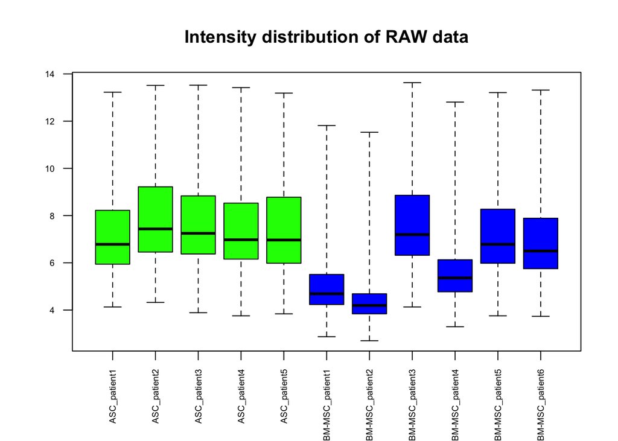

```r
boxplot(rawData, which="all",las=2, main="Intensity distribution of RAW data",
        cex.axis=0.6, names = sampleNames, col=sampleColor)
```

With this boxplot you can clearly see that the data is not normalized and it needs to be done in order to reduce bias.

### Hierarchical clustering

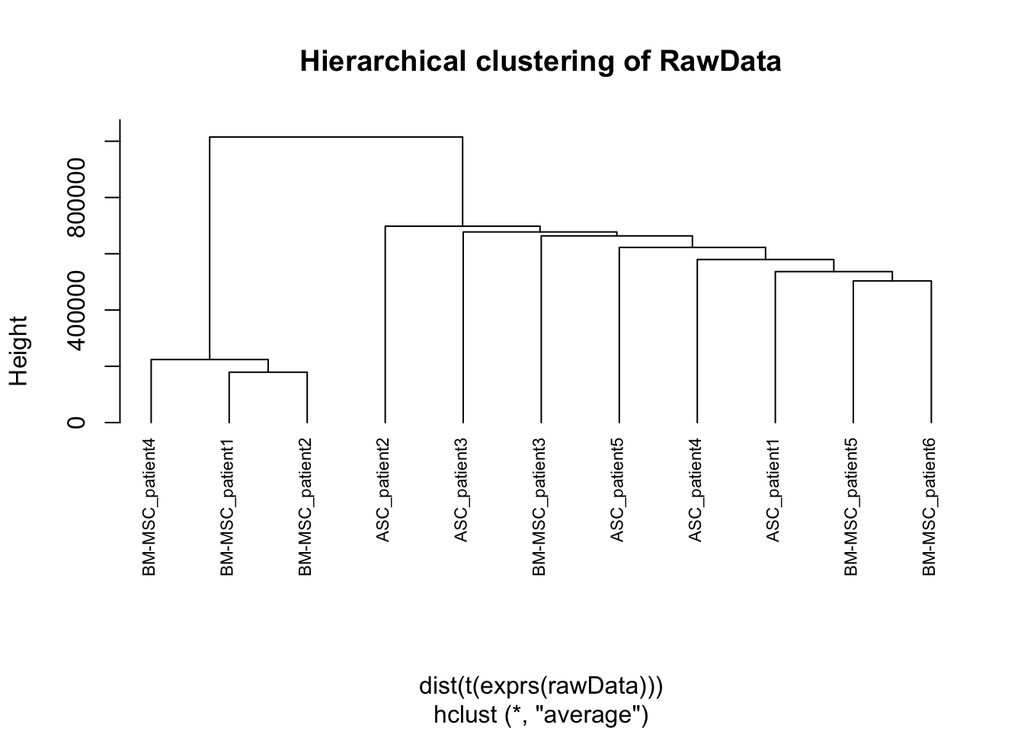

```r
clust.euclid.average <- hclust(dist(t(exprs(rawData))),method="average")
plot(clust.euclid.average, labels=sampleNames, main="Hierarchical clustering of RawData",
     cex=0.7,  hang=-1)
```

You can clearly distinguish two different big clades, one in which it is mainly ghe BM-MSC samples and the other which mainly contains the ASC pacients samples.

### Principal Component Analysis

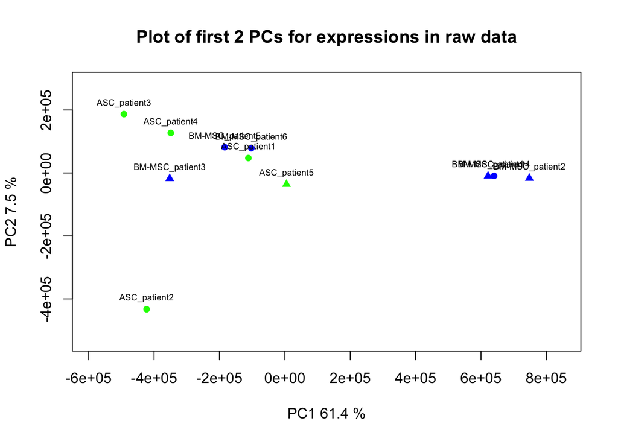

```r
plotPCA <- function ( X, labels=NULL, colors=NULL, dataDesc="", scale=FALSE, formapunts=NULL, myCex=0.8,...)
{
  pcX<-prcomp(t(X), scale=scale) # o prcomp(t(X))
  loads<- round(pcX$sdev^2/sum(pcX$sdev^2)*100,1)
  xlab<-c(paste("PC1",loads[1],"%"))
  ylab<-c(paste("PC2",loads[2],"%"))
  if (is.null(colors)) colors=1
  plot(pcX$x[,1:2],xlab=xlab,ylab=ylab, col=colors, pch=formapunts,
       xlim=c(min(pcX$x[,1])-100000, max(pcX$x[,1])+100000),ylim=c(min(pcX$x[,2])-100000, max(pcX$x[,2])+100000))
  text(pcX$x[,1],pcX$x[,2], labels, pos=3, cex=myCex)
  title(paste("Plot of first 2 PCs for expressions in", dataDesc, sep=" "), cex=0.8)
}
plotPCA(exprs(rawData), labels=sampleNames, dataDesc="raw data", colors=sampleColor,
        formapunts=c(rep(16,4),rep(17,4)), myCex=0.6)
```

### Save to file

```r
pdf(file.path(resultsDir, "QCPlots_Raw.pdf"))
boxplot(rawData, which="all",las=2, main="Intensity distribution of RAW data",
        cex.axis=0.6, col=sampleColor, names=sampleNames)
plot(clust.euclid.average, labels=sampleNames, main="Hierarchical clustering of samples of RawData",
     cex=0.7,  hang=-1)
plotPCA(exprs(rawData), labels=sampleNames, dataDesc="raw data", colors=sampleColor,
        formapunts=c(rep(16,4),rep(17,4)), myCex=0.6)
dev.off()
```

# 3. Normalization

This is done in order to reduce bias, biological variation is minimized so that differences in gene expression can be properly detected. This is done with the raw data.

```r
eset<-rma(rawData)
```

```
## Background correcting
## Normalizing
## Calculating Expression
```

```r
write.exprs(eset, file.path(resultsDir, "NormData.txt"))
```

# 4. Quality assesment of normalized data

I conducted the same steps as in step number 2, and I could see the difference in the plots. For example, the boxplot was unequal without normalization, and after it, all boxes were at the same level.

## Boxplot

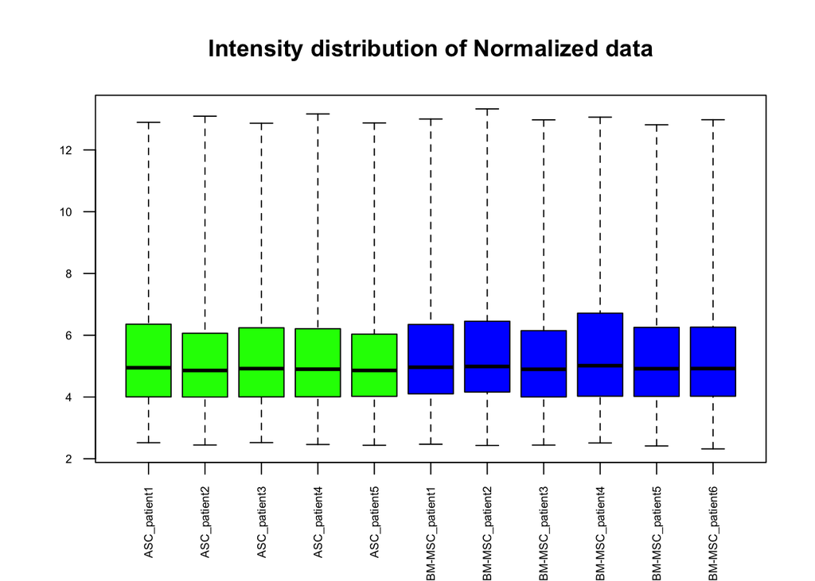

```r
boxplot(eset, las=2, main="Intensity distribution of Normalized data", cex.axis=0.6,
        col=sampleColor, names=sampleNames)
```

It’s different from the non-normalized boxplot, so it can be seen that the normalization can be done.

## Hierarchical clustering

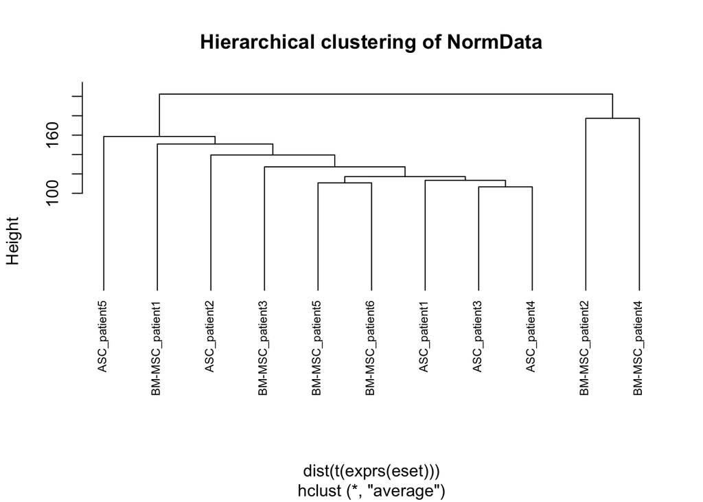

```r
clust.euclid.average <- hclust(dist(t(exprs(eset))),method="average")
plot(clust.euclid.average, labels=sampleNames, main="Hierarchical clustering of NormData",
     cex=0.7,  hang=-1)
```

The clades have changed.

## Principal Component Analysis

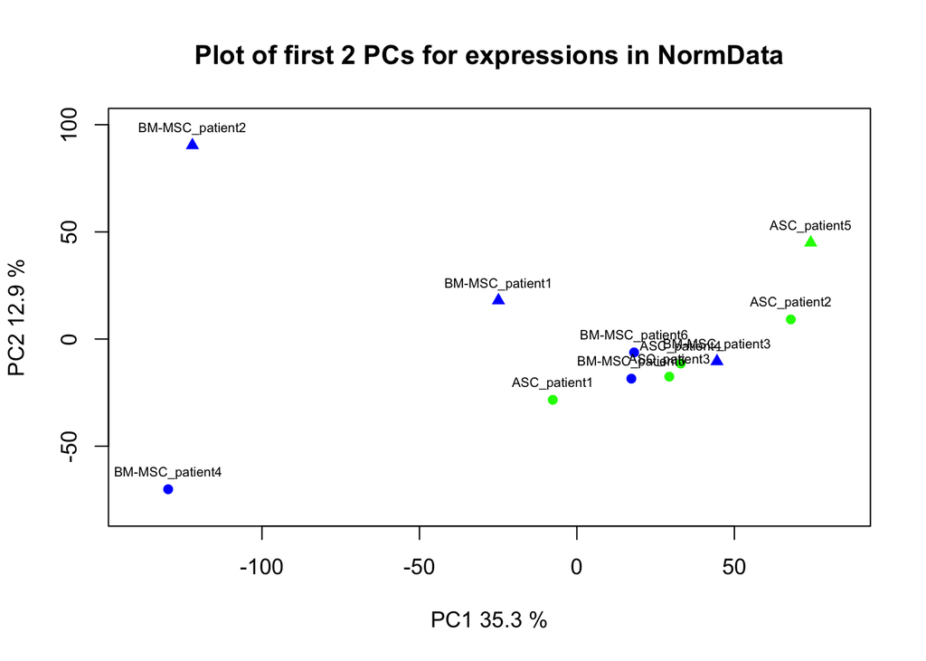

```r
plotPCA <- function ( X, labels=NULL, colors=NULL, dataDesc="", scale=FALSE, formapunts=NULL, myCex=0.8,...)
{
  pcX<-prcomp(t(X), scale=scale) # o prcomp(t(X))
  loads<- round(pcX$sdev^2/sum(pcX$sdev^2)*100,1)
  xlab<-c(paste("PC1",loads[1],"%"))
  ylab<-c(paste("PC2",loads[2],"%"))
  if (is.null(colors)) colors=1
  plot(pcX$x[,1:2],xlab=xlab,ylab=ylab, col=colors, pch=formapunts,
       xlim=c(min(pcX$x[,1])-10, max(pcX$x[,1])+10),ylim=c(min(pcX$x[,2])-10, max(pcX$x[,2])+10))
  text(pcX$x[,1],pcX$x[,2], labels, pos=3, cex=myCex)
  title(paste("Plot of first 2 PCs for expressions in", dataDesc, sep=" "), cex=0.8)
}
plotPCA(exprs(eset), labels=sampleNames, dataDesc="NormData", colors=sampleColor,
        formapunts=c(rep(16,4),rep(17,4)), myCex=0.6)
```

A change between this and the not normalized data can be seen.

## Save to file

```r
pdf(file.path(resultsDir, "QCPlots_Norm.pdf"))
boxplot(eset, las=2, main="Intensity distribution of Normalized data", cex.axis=0.6,
        col=sampleColor, names=sampleNames)
plot(clust.euclid.average, labels=sampleNames, main="Hierarchical clustering of NormData",
     cex=0.7,  hang=-1)
plotPCA(exprs(eset), labels=sampleNames, dataDesc="selected samples", colors=sampleColor,
        formapunts=c(rep(16,4),rep(17,4)), myCex=0.6)
dev.off()
```

# 5. Filtering data

```r
annotation(eset) <- "org.Hs.eg.db"
eset_filtered <- nsFilter(eset, var.func=IQR,
         var.cutoff=0.75, var.filter=TRUE,
         filterByQuantile=TRUE)
#NUMBER OF GENES OUT
print(eset_filtered$filter.log$numLowVar)
```

```
## [1] 40213
```

```r
#NUMBER OF GENES IN
print(eset_filtered$eset)
```

```
## ExpressionSet (storageMode: lockedEnvironment)
## assayData: 13404 features, 11 samples
##   element names: exprs
## protocolData
##   rowNames: GSM3688814_p.15.06.2016_01_AS6.ga.cel
##     GSM3688815_p.15.06.2016_02_AS2.ga.cel ...
##     GSM3688824_p.15.06.2016_12_S19.ga.cel (11 total)
##   varLabels: exprs dates
##   varMetadata: labelDescription channel
## phenoData
##   rowNames: GSM3688814_p.15.06.2016_01_AS6.ga.cel
##     GSM3688815_p.15.06.2016_02_AS2.ga.cel ...
##     GSM3688824_p.15.06.2016_12_S19.ga.cel (11 total)
##   varLabels: index
##   varMetadata: labelDescription channel
## featureData: none
## experimentData: use 'experimentData(object)'
## Annotation: org.Hs.eg.db
```

# 6. Identification of differentially expressed genes

## Linear models

### Contrast Matrix Linear Model

```r
design <-model.matrix(~ 0+targets$Group)
colnames(design)<-c("ASC", "BM_BSC")
rownames(design)<- targets$ShortName
print(design);
```

```
##                 ASC BM_BSC
## ASC_patient1      1      0
## ASC_patient2      1      0
## ASC_patient3      1      0
## ASC_patient4      1      0
## ASC_patient5      1      0
## BM-MSC_patient1   0      1
## BM-MSC_patient2   0      1
## BM-MSC_patient3   0      1
## BM-MSC_patient4   0      1
## BM-MSC_patient5   0      1
## BM-MSC_patient6   0      1
## attr(,"assign")
## [1] 1 1
## attr(,"contrasts")
## attr(,"contrasts")$`targets$Group`
## [1] "contr.treatment"
```

### Comparison

```r
cont.matrix <- makeContrasts (
  ASC_BMBSC = ASC-BM_BSC,
  levels=design)
comparison1 <- "Effect of cells"
```

### Fit linear model

```r
fit1 <- lmFit(eset_filtered$eset, design) # Fits a linear model, solving the equations to obtain the estimates. Estimates parameters using least sqaures
fit.main1 <- contrasts.fit(fit1, cont.matrix)
fit.main1 <- eBayes(fit.main1)
fit.main1
```

[output not shown]

[output cut: 90 more lines]

```
##            ASC_BMBSC
##   16650003 -4.679234
##   16650005 -5.407453
##   16650013 -3.105152
##   16650015 -5.552391
##   16650017 -4.458794
## 13399 more rows ...
##
## $F
## [1] 3.229629 1.575624 7.378844 1.264281 3.761346
## 13399 more elements ...
##
## $F.p.value
## [1] 0.09082204 0.22704628 0.01504134 0.27708820 0.06991437
## 13399 more elements ...
```

## Differential Expressed Genes toptables

```r
topTab <-  topTable(fit.main1, number=nrow(fit.main1), coef=NULL, adjust="fdr")
write.csv2(topTab, file= file.path(resultsDir,paste("Selected.Genes.in.comparison.",
                                                    comparison1, ".csv", sep = "")))
print(xtable(topTab,align="lllllll"),type="html",html.table.attributes="",
      file=paste("Selected.Genes.in.comparison.",comparison1,".html", sep=""))
```

### Volcano plot

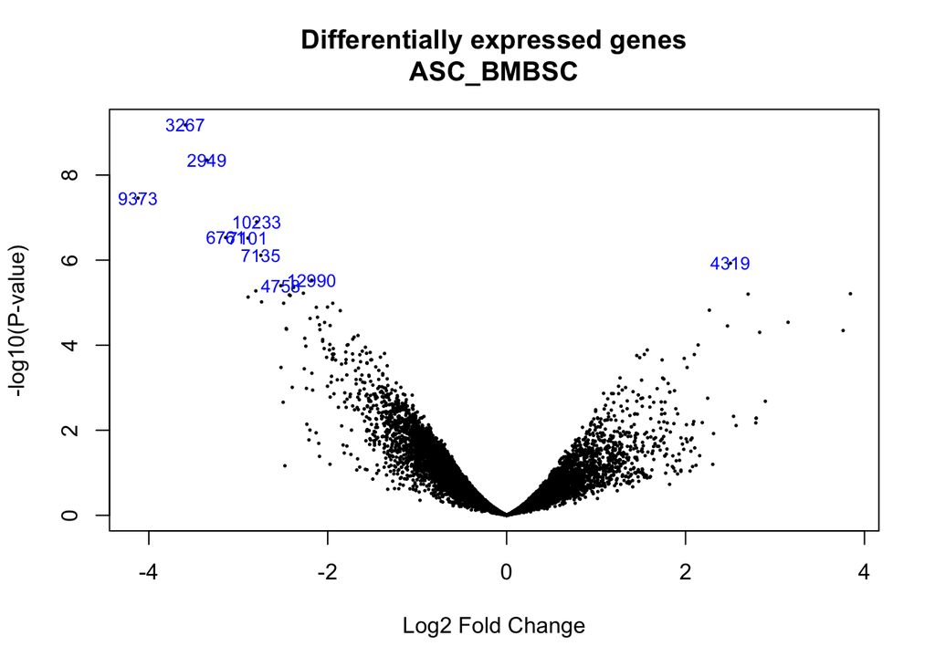

```r
volcanoplot(fit.main1, highlight=10, names=fit.main1$ID,
            main = paste("Differentially expressed genes", colnames(cont.matrix), sep="\n"))
```

```r
pdf(file.path(resultsDir,"Volcanos.pdf"))
volcanoplot(fit.main1, highlight = 10, names = fit.main1$ID,
            main = paste("Differentially expressed genes", colnames(cont.matrix), sep = "\n"))
```

# 7. Annotation

```r
all_anota<-data.frame(exprs(eset))
library(hugene21sttranscriptcluster.db)
Annot <- data.frame(SYMBOL=sapply(contents(hugene21sttranscriptclusterSYMBOL), paste, collapse=", "),
                    DESC=sapply(contents(hugene21sttranscriptclusterGENENAME), paste, collapse=", "))
Annot<-Annot[!Annot$SYMBOL=="NA",]
Annot<-Annot[!Annot$DESC=="NA",]
head(Annot)
```

```
##                SYMBOL                                             DESC
## 16657445        OR4F5 olfactory receptor family 4 subfamily F member 5
## 16657492 LOC105378580                     uncharacterized LOC105378580
## 16657506       FAM87B      family with sequence similarity 87 member B
## 16657514    LINC01128      long intergenic non-protein coding RNA 1128
## 16657529    LOC284600                        uncharacterized LOC284600
## 16657534       SAMD11         sterile alpha motif domain containing 11
```

```r
anotaGenes <- merge(Annot,all_anota, by.x=0,by.y=0)
head(anotaGenes)
```

```
##   Row.names       SYMBOL                                             DESC
## 1  16657445        OR4F5 olfactory receptor family 4 subfamily F member 5
## 2  16657492 LOC105378580                     uncharacterized LOC105378580
## 3  16657506       FAM87B      family with sequence similarity 87 member B
## 4  16657514    LINC01128      long intergenic non-protein coding RNA 1128
## 5  16657529    LOC284600                        uncharacterized LOC284600
## 6  16657534       SAMD11         sterile alpha motif domain containing 11
##   GSM3688814_p.15.06.2016_01_AS6.ga.cel
## 1                              3.781555
## 2                              5.938068
## 3                              6.303339
## 4                              7.082904
## 5                              7.884876
## 6                              5.324637
##   GSM3688815_p.15.06.2016_02_AS2.ga.cel
```

[output cut: 69 more lines]

```r
write.table(anotaGenes, file ="data.ann.txt",sep="\t")

rownames(anotaGenes) <- anotaGenes[,1]
anotaGenes <- anotaGenes[,-1]
anotaGenes.end <- merge(anotaGenes, topTab, by.x=0,by.y=0)

# topTab.end = anotaGenes.end
topTab.end <- anotaGenes.end[order(-anotaGenes.end$B),]

rownames(topTab.end) <- topTab.end[,1]
topTab.end <- topTab.end[, -1]
write.csv(topTab.end, file = file.path(resultsDir,"TopTable.end.csv"))
```

# 8. Multiple Comparisons

As I just had two groups, I only had one comparison, which you can find when identifying the differential genes. For the comparison, what we did is the contrast matrix, fitting the linear model with the expression set and finally fitting what we have done, which got me different coefficients and standard errors.

# 9. Functional Interpretation